# Visualizing Bike Share

# Introduction

This tutorial will cover exploring and visualizing data through 2018 for the Minneapolis, MN bike sharing service NiceRide. Part of what makes R incredible is the number of great packages. Part of what makes packages like ggmap and gganimate great is how they build on existing packages.

# Get Data

```r
url <- "https://s3.amazonaws.com/niceride-data/index.html"
repo <- url %>% read_html
tbls <- html_nodes(repo, "table")

url <- "https://s3.amazonaws.com/niceride-data/"
repo <- url %>% read_html %>% xml_child(1) %>% xml_child(1) %>% xml_find_all(".//key")
repo[1:10]
```

```
## {xml_nodeset (10)}
##  [1] <key>201804-niceride-tripdata.csv.zip</key>
##  [2] <key>201805-niceride-tripdata.csv.zip</key>
##  [3] <key>201806-niceride-tripdata.csv.zip</key>
##  [4] <key>201807-niceride-tripdata.csv.zip</key>
##  [5] <key>201808-niceride-tripdata.csv.zip</key>
##  [6] <key>201809-niceride-tripdata.csv.zip</key>
##  [7] <key>201810-niceride-tripdata.csv.zip</key>
##  [8] <key>201811-niceride-tripdata.csv.zip</key>
##  [9] <key>201904-niceride-tripdata.csv.zip</key>
## [10] <key>201905-niceride-tripdata.csv.zip</key>
```

```r
repo %<>% as_list %>% unlist %>% str_match_all("^2018.*") %>% unlist
```

## Downloading and Unzipping

You could merge both actions into one loop, but I made two loops. The`%T>%` operator comes in handy here to unlink the concatenated filename instead of the return of unzip.

```r
# No need to repeat
dir.create("import")
# Download Files
for(file in repo) {download.file(paste0(url,file),destfile = paste0("import/",file)) }
# Unzip
for(file in repo) {paste0("import/",file) %T>% unzip(exdir = "import") %>% unlink
}
```

## Read and Merge into a Dataframe

Now that we have the files unzipped we can read them into a list and merge the list into a dataframe. You could do this manually, but this will allow for you to change the year easily, or merge 2018 and 2017 into a dataframe to company ridership between years.

```r
# Read and merge
import <- lapply("./import" %>% list.files, function(name) {return(read_csv(paste0("./import/", name)))})
rides <- rbindlist(import, fill = T)
rides %<>% clean_names(case = "snake")
```

Additional Columns Now that we have the data in rides, we can build some extra columns/features. Age is a much more intuitive field than birth_year, and grouping ages into bins will come in handy later.

```r
rides$age <- 2019-rides$birth_year
rides$age_bin <- rides$age %>% .bincode(seq(0,120,20))
rides$age_bin <- sapply(rides$age_bin,function(bin) {return(paste0((bin-1)*20,"-",(bin*20)," Years Old"))})
```

We probably will want to see things in a more macro level view, so we should build out some date/time columns as well.

```r
# Trip times
rides$minutes <- rides$tripduration/60
rides$hours <- rides$tripduration/60/60
# Start times
rides$start_hour <- lubridate::hour(rides$start_time)
rides$mm <- hour(rides$start_time)*60 + minute(rides$start_time)
rides$start_day <- wday(rides$start_time,label =  T, abbr = F, week_start = 1)
# Weekend/Weekday
rides$start_day_type <- ifelse(wday(rides$start_time, week_start = 1)>5, "Weekend", "Weekday")
# Week of year
rides$week <- week(rides$start_time)
# Month (1-12)
rides$month <- month(rides$start_time,label = T,abbr = F)
# Month (January-December)
rides$month_text <- month(rides$start_time,label = T,abbr = F)
# Remove unused levels from factor
rides$month_text <- droplevels(rides$month_text)
```

You can print the info in a different way, I am just doing this to format everything better for the web.

```r
table(rides$age_bin) %>% lapply({. %>% format(big.mark=",") %>% return})
```

```
## $`0-20 Years Old`
## [1] "5,880"
##
## $`100-120 Years Old`
## [1] "17"
##
## $`20-40 Years Old`
## [1] "145,965"
##
## $`40-60 Years Old`
## [1] "240,249"
##
## $`60-80 Years Old`
## [1] "19,894"
##
## $`80-100 Years Old`
## [1] "418"
```

From this we can see that tossing out anything below a half a percent would remove 80-100 and 100-120. We could probably remove 0-20 as well, but that is up to you.

# The Delicious Part

Now comes the time to visually explore the data. For the same of simplicity I am just using `theme_fivethirtyeight()` and `scale_.*_viridis.*()` for the theme and colors of most of these plots.

## Visualizing Ridership by Month

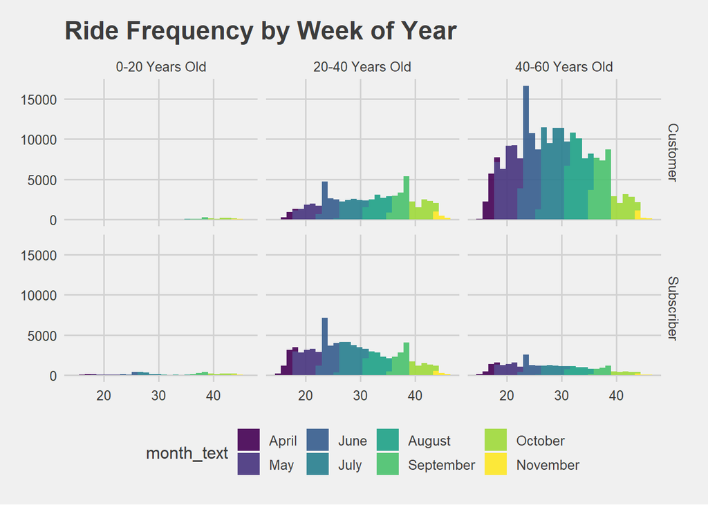

```r
ggplot(data = rides[which(rides$age <= 60),], aes(x = week, fill = month_text)) +
  geom_histogram(alpha = .9) + theme_fivethirtyeight() + ggtitle("Ride Frequency by Week of Year") +
  facet_grid(vars(usertype), vars(age_bin)) + scale_fill_viridis_d()
```

```r
#ggsave(filename = "ride-frequecy-histogram.png", width = 8, units = "in")
```

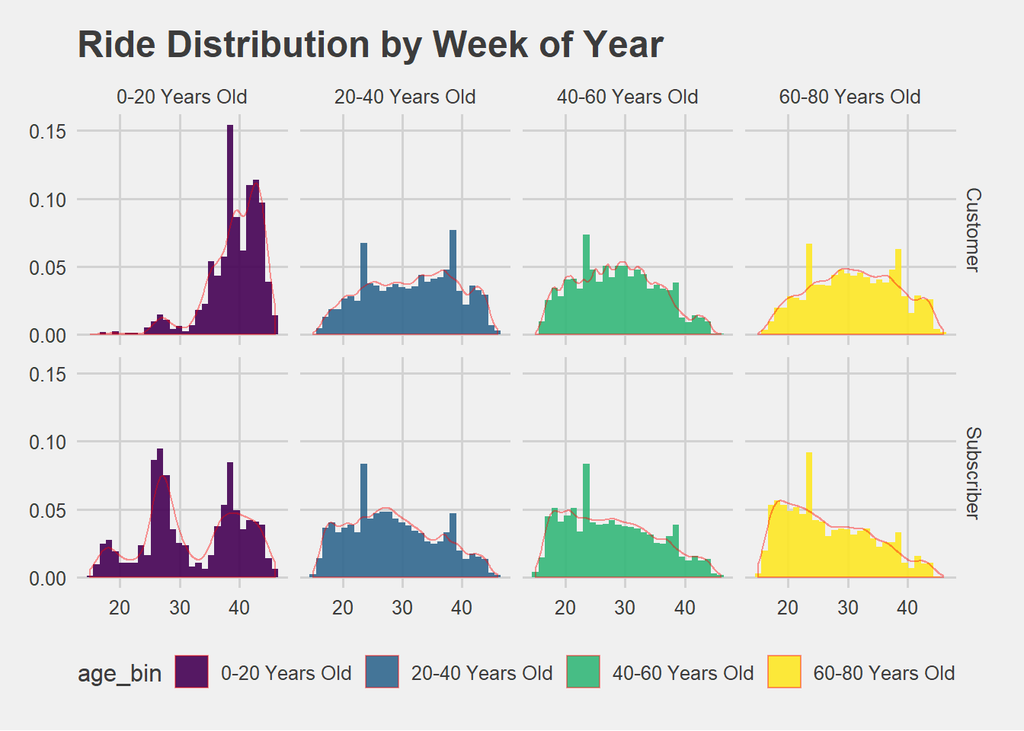

```r
ggplot(data=rides[which(rides$age <= 80),], aes(x = week, fill = age_bin)) +
  geom_histogram(alpha = .9, aes(y = ..density..)) + theme_fivethirtyeight() + ggtitle("Ride Distribution by Week of Year") +
  geom_density(alpha = 0, color = rgb(1,0,0,.4)) +
  facet_grid(vars(usertype), vars(age_bin)) + scale_fill_viridis_d()
```

```r
#ggsave(filename = "ride-frequency-density.png", width = 8,units = "in")
```

Looks like we are seeing a downward trend toward the end of the year for subscribers/20-80 and customers/20-80 with the biggest downward trends for subscribers/60-80. Makes sense, from the previous plot we saw week 40 fell in October and Minneapolis can get chilly.

## Visualizing Start Time

I also added breaks and labels for the time to correspond with peak times.

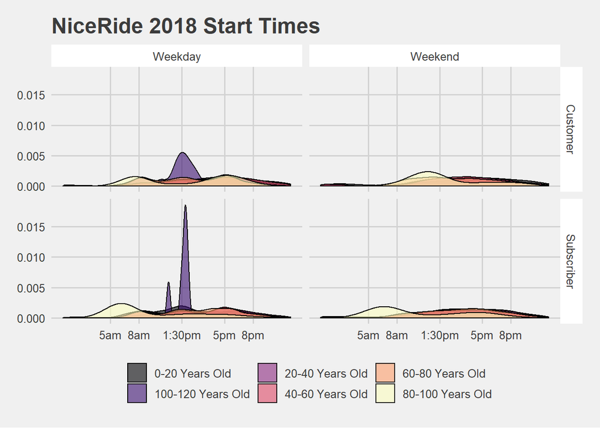

```r
ggplot(rides, aes(x = mm, fill = age_bin)) + geom_density(alpha = .6) +
scale_x_continuous(labels = c("5am", "8am", "1:30pm", "5pm", "8pm"),breaks = c(300, 480, 750, 1020, 1200)) +
labs(fill = "", title = "NiceRide 2018 Start Times") +
theme_fivethirtyeight() + theme(strip.background = element_rect(fill = "#FFFFFF")) +
facet_grid(vars(usertype), vars(start_day_type)) + scale_fill_viridis_d(option = "A")
```

This plot gives us a lot of really interesting information! You can see how NiceRide is used by many people who are presumably commuting. There is also a lunch rush for NiceRide bikes.

## Maps!

So far all of this information has been on a macro level for time based ridership. Now we will switch to location based ridership.

### Static Network Map

In order to generate static heatmaps we will be using the ggmap package along with the ggplot2::geom_segment() function. There is also a ggplot2::geom_curve() function which you can use to generate curved line segments. For the curved line segments you must also use coord_cartesian()

In order to speed up the rendering of geom_segment() I aggregated the data and then scaled the opacity of the line segments. I don’t think this was a necessary step, but it made rendering (and tweaking the plot) much easier.

```r
df.lines <- rides %>% group_by(start_station_longitude, start_station_latitude,
                               end_station_longitude, end_station_latitude,
                               start_station_name, end_station_name) %>%
     summarize(rides = n())
```

Now we have a handy dandy dataframe which has the number of rides between stations. The start_station_name and end_station_name are not required, but they are helpful if you want to further explore station data. You can also summarize on the fly for station information with plyr

```r
rides %>% group_by(start_station_name, end_station_name) %>%
  filter(start_station_name != "NULL") %>%
  summarize(rides = n()) %>% ungroup %>% top_n(10)
```

```
## # A tibble: 10 x 3
##    start_station_name                end_station_name                 rides
##    <chr>                             <chr>                            <int>
##  1 100 Main Street SE                100 Main Street SE                1161
##  2 11th Ave S & S 2nd Street         11th Ave S & S 2nd Street         1436
##  3 6th Ave SE & University Ave       6th Ave SE & University Ave       1148
##  4 Lake Calhoun Center               Lake Calhoun Center               2804
##  5 Lake Como Pavilion                Lake Como Pavilion                2070
##  6 Lake Harriet Bandshell            Lake Harriet Bandshell            2332
##  7 Lake Street & Knox Ave S          Lake Street & Knox Ave S          6852
##  8 Minnehaha Park                    Minnehaha Park                    1673
##  9 W 36th Street & W Calhoun Parkway W 36th Street & W Calhoun Parkw~  2012
## 10 Weisman Art Museum                Willey Hall                       1081
```

Neat, right? Also, that Lake Street & Knox Ave S location had over six thousand round trips. Also pretty interesting that all of the top 10 were round trips except for Weisman Art Museum/Willey Hall. Changing to the top 20 stations we see that pop four times as a starting station.

## Getting the Base Map

The package `ggmap` has a function called `get_map()` which we will be using. You can pass the name of the city, but I am passing the boundaries of our start/end coordinates.

```r
# First you will need a Google API Key https://developer.here.com/sign-up?create=Freemium-Basic&keepState=true&step=account
register_google(key = "x5YItrv8sdduJAgBdK7mWbGZ8_-HagaosjkGHqfPTRw")
mpls <- get_map(c(left = min(rides$start_station_longitude), bottom = min(rides$start_station_latitude),
                  right = max(rides$start_station_longitude), top = max(rides$start_station_latitude)),
                maptype='terrain', source='stamen', zoom=13)
```

Now that we have our city mpls tiles, we can add some layers, including our geom_segment() layer. The function scale_alpha() was a lifesaver here, and without that we wouldn’t have been able to aggregate our data in df.line as the whole plot would be either blacked out when using aes() or not determined by df.line$rides. The function theme_nothing() comes from ggmap and is useful for removing axis labels among other attributes.

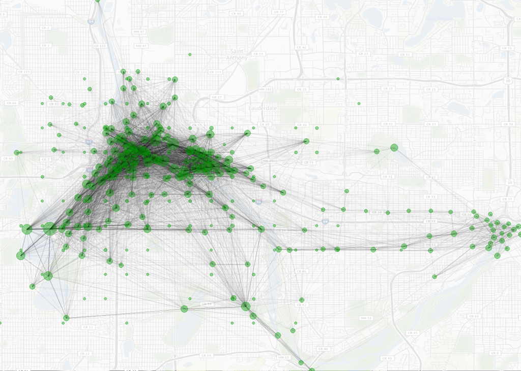

```r
# Darken allows us to lighten up the map
ggmap(mpls,darken = c(.8,"#FFFFFF")) +
  geom_segment(data = df.lines,
               aes(x = start_station_longitude,
                   y = start_station_latitude,
                   xend = end_station_longitude,
                   yend = end_station_latitude,
                   alpha = sqrt(rides)),
               color = "#000000") + coord_cartesian() +
  scale_alpha(range = c(0.0001, .5)) +
  geom_point(data = df.lines %>%
               group_by(longitude = start_station_longitude,
                        latitude = start_station_latitude) %>%
               summarize(rides = sum(rides)),
             aes(x = longitude,
                 y = latitude,
                 size = rides),
             color="#009900",alpha=.4) +
  scale_size_continuous(range(4,100)) +
  scale_color_viridis_c() +
  scale_fill_viridis_c() +
  theme_nothing()
```

```r
#ggsave(filename = "station-network.jpg",width = 8,units = "in")
```

I made the executive decision to aggregate data for geom_point() on the fly. Without aggregating, we would be left with multiple points for each start station.

Some of those roundtrips threw off the scale, which is why sqrt() is used. You could substitute sqrt() for log(), but I found the results more palatable as written.

There are a couple of insights to be garnered from this plot. There is a nice little rectangle of trips down at the bottom along Minnehaha Creak, the chain of lanes, and then on Lake Street and either West River Parkway or Hiawatha. There is also a ton more activity in Minneapolis than St. Paul, as expected. This might also be a good reference for where to put additional NiceRide stations. You may want to first replace geom_segment() with geom_path() from the ggmap::route() function which I will go over in another, shorter tutorial.

## Leaflet Interactive Map

This one also required a new dataframe. Essentially we are summarizing the start stations and end stations separately so we can see if there is a change in the heatmap when cycling between the two layers.

```r
df.heatmap.start_end <- list()
df.heatmap.start_end$start <- rides %>%
  group_by(start_station_longitude, start_station_latitude) %>%
  summarize(intensity = sqrt(n()))
names(df.heatmap.start_end$start)[1:2] <- c("longitude","latitude")

df.heatmap.start_end$end <- rides %>%
  group_by(end_station_longitude, end_station_latitude) %>%
  summarize(intensity = sqrt(n()))
names(df.heatmap.start_end$end)[1:2] <- c("longitude","latitude")

df.heatmap.start_end$start$pos <- "Start"
df.heatmap.start_end$end$pos <- "End"

df.heatmap.start_end %<>% rbindlist(fill = T)
```

## Hot Hot Heat

You don’t have to add two layers of heatmaps, but you can! I segmented the data between start and stop to see if there was any change. The function addLayersControl() will allow us to toggle between the two layers. You can tweak the parameters to your liking, but I found these settings produced a plot I was happy with.

```r
leaflet(df.heatmap.start_end) %>%
  addProviderTiles(providers$CartoDB.DarkMatter) %>%
  addHeatmap(data = df.heatmap.start_end %>% filter(pos=="Start"),
             lng=~longitude,
             lat=~latitude,
             intensity = ~intensity,
             blur = 10,
             max = 100, radius = 15,
             layerId = "Start", group = "Start") %>%
  addHeatmap(data = df.heatmap.start_end %>% filter(pos=="End"),
             lng=~longitude,
             lat=~latitude,
             intensity = ~intensity,
             blur = 10,
             max = 100, radius = 15,
             layerId = "End", group = "End") %>%
  addLayersControl(
    baseGroups = c("Start","End"),
    options = layersControlOptions(collapsed = FALSE)
  )
```

[interactive chart not shown]

# Reference

https://www.r-bloggers.com/visualizing-bike-share-data-niceride/